# MVP EDA

Here are two quick ways to get a visual sense of your data. One is for continuous data and the other is for catigorcal. All examples use the The [titanic dataset](https://www.kaggle.com/c/titanic/data) from kaggle

```python
df.head()
```

| PassengerId | Survived | Pclass | Name | Sex | Age | SibSp | Parch | Ticket | Fare | Cabin | Embarked |
| --- | --- | --- | --- | --- | --- | --- | --- | --- | --- | --- | --- |
| 1 | 0 | 3 | Braund, Mr. Owen Harris | male | 22.0 | 1 | 0 | A/5 21171 | 7.2500 | NaN | S |
| 2 | 1 | 1 | Cumings, Mrs. John Bradley (Florence Briggs Th... | female | 38.0 | 1 | 0 | PC 17599 | 71.2833 | C85 | C |
| 3 | 1 | 3 | Heikkinen, Miss. Laina | female | 26.0 | 0 | 0 | STON/O2. 3101282 | 7.9250 | NaN | S |
| 4 | 1 | 1 | Futrelle, Mrs. Jacques Heath (Lily May Peel) | female | 35.0 | 1 | 0 | 113803 | 53.1000 | C123 | S |
| 5 | 0 | 3 | Allen, Mr. William Henry | male | 35.0 | 0 | 0 | 373450 | 8.0500 | NaN | S |

Lets put the top five family names in as dummies

```python
# get family name from Name column
df['family_name'] = [x.split(',')[0] for x in df['Name']]

Top5Fam = df['family_name'].value_counts()[:5].index # Store the list of names

# make a column in the data frame for each value, and fill it with the dummy info
for fam_name in Top5Fam:
    df[fam_name] = [x == fam_name for x in df['family_name']]
```

```python
df.dropna(inplace=True) # Sns pairplot does not like NaN
```

Here is a very simple line of code I like to throw out early on to get a *broad* sense of whats going on. As you can see it works best to understand the relationship between continuous variables.

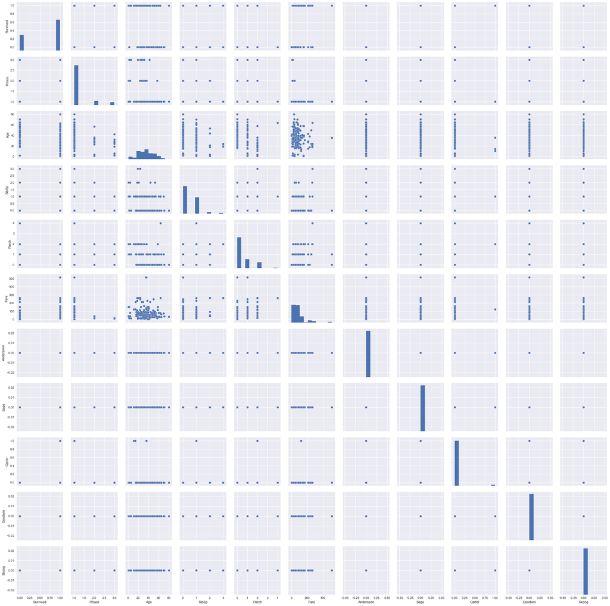

```python
%matplotlib inline
sns.pairplot(df)
```

Lets try it agin filtering the data frame to just continous variables

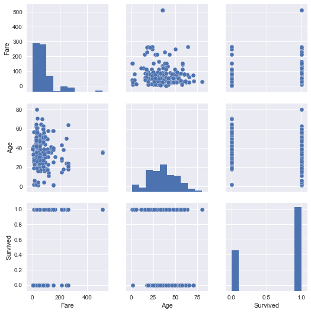

```python
# Kept Survived in there as it's the y for this data
sns.pairplot(df[['Fare' ,'Age' ,'Survived']])
```

Immediately you can see outliers in age and fair or perhaps a row with fair and age switched? But what about categorical data?  
Lets filter the data down to the five most common family names and see how they faired.

```python
# Fun fact, if a list comprehension is the same length as a data frame
# you can use it as a filter.

dfT5 = df[[x in Top5Fam for x in df['family_name']]]
```

```python
# But we both know my love of list comprehensions is getting out of hand
# so here is the pythonic? pandonic? way to filter a column for specific values

dfT5 = df[df['family_name'].isin(Top5Fam)] # more readable for sure
```

[figure not shown]

```python
sns.swarmplot(x="family_name", y="Fare",hue="Survived", data=dfT5)
```

[output not shown]

The seaborn swarm plot code is so easy to read and manipulate you can imagine swapping in variable to do first round EDA.